Participant Info Name: Moritz Madern Mail:moritz.madern@meduniwien.ac.at

## Setup

```r
## Load packages
library(tidyverse)
library(janitor)
library(tableone)
library(survival)
library(ggsurvfit)
library(splines)
library(nnet)


## Read in data
df <- read.delim(file="../data/cleaned_data.csv", sep=",", header=TRUE)
```

```r
## Define relevant objects
dict_drugs <- setNames(c("Clopidogrel", "Prasugrel", "Ticagrelor"),
                       nm=c("B01AC04", "B01AC22", "B01AC24"))

## Create variable time_to_event_years (existing olumn time_to_event is saved as time to event in days)
df$time_to_event_years <- df$time_to_event/365.25


## Create Column of inhibitors (with names instead of ATC code)
df$drugname <- dict_drugs[df$inhibitor]
df$drugname <- dict_drugs[df$inhibitor] %>% factor(., levels=c("Clopidogrel", "Prasugrel", "Ticagrelor"))


## Change class of some variables to the type that will be used in modeling
df <- df %>% mutate(year_of_start = factor(as.character(year_of_start), levels=c("2020", "2021", "2022")))
df$sex <- factor(df$sex, levels=c("m", "f"))
```

## Main Analysis: unadjusted Kaplan-Meier Plot stratified by the three treatment groups (i.e. no covariate adjustment whatsoever)

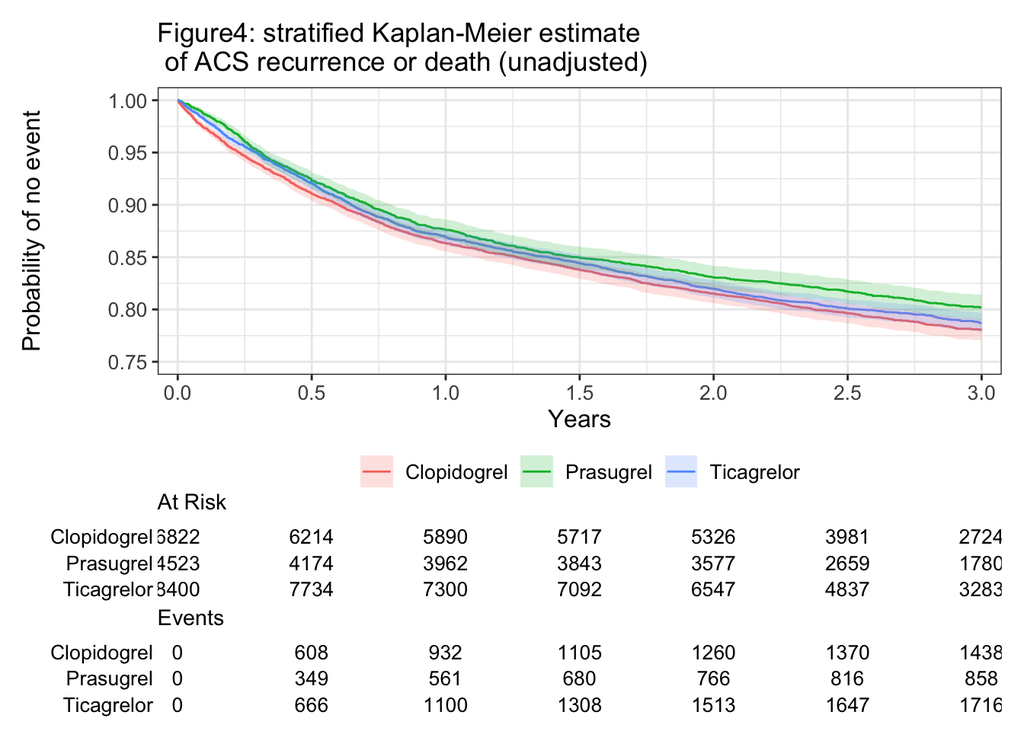

```r
## Fit overall KM + 95%CI for time until ACS recurrence or death
Fig4 <- survfit2(Surv(time_to_event_years, last_status) ~ drugname, df,  conf.int = 0.95) %>%
    ggsurvfit() +
    add_confidence_interval() +
    add_risktable() +
    scale_ggsurvfit() +
    ylab("Probability of no event") +
    xlab("Years") + ggtitle("Figure4: stratified Kaplan-Meier estimate \n of ACS recurrence or death (unadjusted)") +
    ylim(0.75,1)
print(Fig4)
```

```r
ggsave(filename = "../output/figures/Fig4__MainAnalysis_stratifiedKM_unadjusted.pdf", plot=Fig4)
```

Note: Fig4 shows unadjusted KM curves. The SAP here reads: “A Kaplan-Meier plot stratified by the three treatment groups will be created”. Since there was no mention of “adjusted” or “IPTW-weighted”, I figured it was the unadjusted KM curves that were desired.

## Main Analysis: Marginal Survival Curves + MRST using double-robust estimation

```r
## Find adequate transformations of adjustment covariates


# 1)
df$age_in_years <- df$age_in_years # stays the same (continuous)
# 2)
df$sex <- df$sex # stays the same (binary)
# 3)
df$year_of_start <- df$year_of_start # stays the same (categorical)
# 4)
df$log_days_in_hosp__hosp <- log(df$days_in_hosp__hosp + 1) # log(x+1) transformation seems reasonable since right-skewed; (continuous)
# 5)
df$cut_days_in_hosp_eligibility <- cut(df$days_in_hosp__eligibility, # creates a separate category for 0 days in hospital during eligibility period (most cases!) which seems reasonable; (categorical)
                                       breaks = c(0,1,5,10,max(df$days_in_hosp__eligibility)), include.lowest = TRUE,
                                       right=FALSE)
# 6)
df$cut_number_com_ICD__hosp <- cut(df$number_com_ICD__hosp, # creates a separate category for only one ICD code (minimal number) which seems reasonable; (categorical)
                                   breaks=c(0,2,3,4, max(df$number_com_ICD__hosp)), include.lowest = TRUE,
                                   right = FALSE)
# 7)
df$cut_number_com_ICD__eligibility <- cut(df$number_com_ICD__eligibility, # creates a separate category for only 0 ICD codes (minimal number) which seems reasonable; (categorical)
                                          breaks=c(0,1,2,max(df$number_com_ICD__eligibility)), include.lowest = TRUE,
                                          right=FALSE)
# 8)
df$cut_total_redemptions__eligibility <- cut(df$total_redemptions__eligibility, # creates a separate category for only 0 redemtpions which seems reasonable; (categorical)
                                             breaks=c(0,1,5,20,max(df$total_redemptions__eligibility)), include.lowest = TRUE,
                                             right=FALSE)
# 9)
# Binary variables for types of co-medication in eligibility period (A10A A10B B01 R01 R03 C01 C02 C03 C07 C08 C09 C10); (all binary)
```

Note: For many of the interger variables (e.g., number_com_ICD__hosp), I ultimately decided on categorical variable transformations that include a separate category for the lowest count possible. The idea behind this decision was the reasoning that a jump from 0 to 1 has a different meaning than e.g. a jump from 4 to 5 (the latter jump might be negligible). Further, I kept the number of categories small to ensure sufficient observations within each bin.

```r
# ## Fit a simplified multinomial logistic regression model (Clopidogrel is reference/baseline level) just to test MLR modeling and predictions
# mlr_fit <- nnet::multinom(formula = drugname ~ age_in_years + sex, data = df)
#
#
# ## Check predictions for new ids (first one, then two)
# df_new_patient <- data.frame(
#   age_in_years = 65,
#   sex = "m"
# )
# df_new_patients <- data.frame(
#   age_in_years = c(65, 20),
#   sex = c("m", "f")
# )
# predict(mlr_fit, newdata = df_new_patient, type = "probs")
# predict(mlr_fit, newdata = df_new_patients, type = "probs") # first row: Probabilities for first patient; second row: Probabilities for second patient
#
#
# ## Check if model predictions via predict() are the same as when calculated manually
# X <- matrix(c(1, 65, 1), nrow=1)
# m_mlr_coeff <- coefficients(mlr_fit)
# eta <- X %*% t(m_mlr_coeff)
# p_Clopidogrel = 1/(1 + sum(exp(eta)))
# p_Clopidogrel
# p_Prasugrel <- exp(eta[,"Prasugrel"])/(1 + sum(exp(eta)))
# p_Prasugrel
# p_Ticagrelor <- exp(eta[,"Ticagrelor"])/(1 + sum(exp(eta)))
# p_Ticagrelor
#
#
# ## Note: Both identical!
# mlr_fit1 <- nnet::multinom(formula = drugname ~ splines::ns(df$age_in_years, knots = quantile(age_in_years, probs = c(0.333,0.67)))  + sex, data = df)
# coefficients(mlr_fit)
# mlr_fit2 <- nnet::multinom(formula = drugname ~ splines::ns(df$age_in_years, knots = quantile(df$age_in_years, probs = c(0.333,0.67)))  + sex, data = df)
# coefficients(mlr_fit2)
```

```r
## Fit the multinomial logistic regression model (Comment-AI: provided information on recommended package for MLR modeling)
set.seed(123)
mlr_fit <- nnet::multinom(formula = drugname ~
                            splines::ns(age_in_years, knots = quantile(age_in_years, probs = c(0.333,0.67))) +
                            sex +
                            year_of_start +
                            splines::ns(log_days_in_hosp__hosp, knots = quantile(log_days_in_hosp__hosp, probs = c(0.333,0.67))) +
                            cut_days_in_hosp_eligibility +
                            cut_number_com_ICD__hosp +
                            cut_number_com_ICD__eligibility +
                            cut_total_redemptions__eligibility +
                            A10A + A10B + B01 + R01 + R03 + C01 + C02 + C03 + C07 + C08 + C09 + C10,
                            data = df)
```

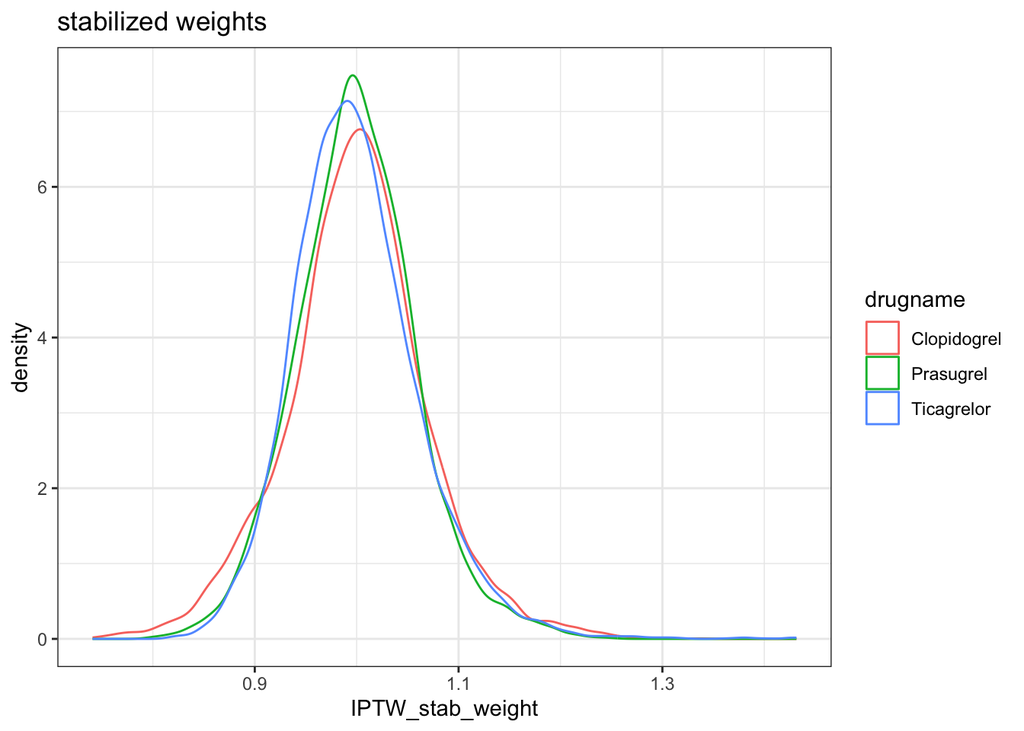

```r
## Predict probabilities for treatment with specific inhibitor for each patient. Then add those predictions to df
df_prob_inhib <- as.data.frame(predict(mlr_fit, newdata = df, type = "probs")) %>%
                    rename(prob_Clopidogrel = Clopidogrel,
                           prob_Prasugrel = Prasugrel,
                           prob_Ticagrelor = Ticagrelor)
df <- cbind(df, df_prob_inhib)



## Calculate IPTW weights (both stabilized and unstabilized; I want to compare them)
p_marginal <- prop.table(table(df$drugname)) # calculate marginal treatment probabilities (Comment-AI: AI helped me understand and use these stabilized weights)
df <- df %>% mutate(IPTW_weight = case_when(
                                      drugname == "Clopidogrel" ~ 1/prob_Clopidogrel,
                                      drugname == "Prasugrel" ~ 1/prob_Prasugrel,
                                      drugname == "Ticagrelor" ~ 1/prob_Ticagrelor
                                  ),
                    IPTW_stab_weight = case_when(
                                      drugname == "Clopidogrel" ~ p_marginal["Clopidogrel"]/prob_Clopidogrel,
                                      drugname == "Prasugrel"   ~ p_marginal["Prasugrel"]/prob_Prasugrel,
                                      drugname == "Ticagrelor"  ~ p_marginal["Ticagrelor"]/prob_Ticagrelor
                                  )
                    )


## Check the distribution of the weights (stabilized)
Fig5 <- ggplot(data=df) +
  geom_density(aes(x=IPTW_stab_weight, col=drugname)) + ggtitle("stabilized weights") + theme_bw()
print(Fig5)
```

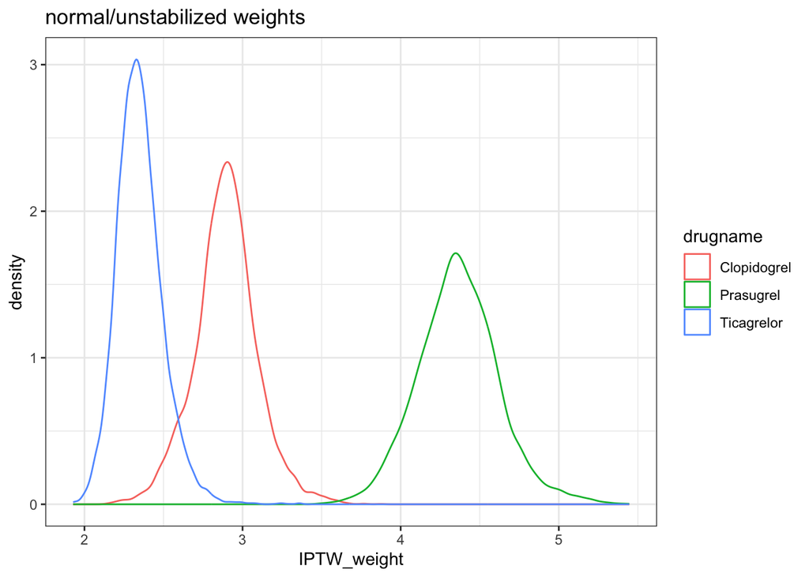

```r
ggsave(filename = "../output/figures/Fig5__MainAnalysis_Density_stabilized_weights.pdf", plot=Fig5)
## Check the distribution of the weights (normal/unstabilized)
Fig6 <- ggplot(data=df) +
  geom_density(aes(x=IPTW_weight, col=drugname)) + ggtitle("normal/unstabilized weights") + theme_bw()
print(Fig6)
```

```r
ggsave(filename = "../output/figures/Fig6__MainAnalysis_Density_unstabilized_weights.pdf", plot=Fig6)
## Check summary of the weights (assesment: the weights are totally fine)
summary(df$IPTW_weight)
```

```
##    Min. 1st Qu.  Median    Mean 3rd Qu.    Max.
##   1.928   2.365   2.766   3.000   3.202   5.445
```

```r
quantile(df$IPTW_weight, probs = c(0.95, 0.99))
```

```
##      95%      99%
## 4.549421 4.815284
```

```r
summary(df$IPTW_stab_weight)
```

```
##    Min. 1st Qu.  Median    Mean 3rd Qu.    Max.
##  0.7408  0.9598  0.9976  1.0000  1.0370  1.4316
```

```r
quantile(df$IPTW_stab_weight, probs = c(0.95, 0.99))
```

```
##      95%      99%
## 1.107914 1.177172
```

Interpretation of weights: They seem to be fine; i.e. there are no huge outliers due to extremely low estimated probabilities.

```r
## Fit a Cox model without weights
# coxph_drugs <- survival::coxph(survival::Surv(time_to_event_years, event=last_status) ~
#                                                         drugname +
#                                                         splines::ns(age_in_years, knots = quantile(age_in_years, probs = c(0.333,0.67))) +
#                                                         sex +
#                                                         year_of_start +
#                                                         splines::ns(log_days_in_hosp__hosp, knots = quantile(log_days_in_hosp__hosp, probs = c(0.333,0.67))) +
#                                                         cut_days_in_hosp_eligibility +
#                                                         cut_number_com_ICD__hosp +
#                                                         cut_number_com_ICD__eligibility +
#                                                         cut_total_redemptions__eligibility +
#                                                         A10A + A10B + B01 + R01 + R03 + C01 + C02 + C03 + C07 + C08 + C09 + C10,
#                                                    data=df)


## Fit weighted Cox model with weights derived from MLR model
coxph_drugs_weighted <- survival::coxph(survival::Surv(time_to_event_years, last_status) ~
                                                        drugname +
                                                        splines::ns(age_in_years, knots = quantile(age_in_years, probs = c(0.333,0.67))) +
                                                        sex +
                                                        year_of_start +
                                                        splines::ns(log_days_in_hosp__hosp, knots = quantile(log_days_in_hosp__hosp, probs = c(0.333,0.67))) +
                                                        cut_days_in_hosp_eligibility +
                                                        cut_number_com_ICD__hosp +
                                                        cut_number_com_ICD__eligibility +
                                                        cut_total_redemptions__eligibility +
                                                        A10A + A10B + B01 + R01 + R03 + C01 + C02 + C03 + C07 + C08 + C09 + C10,
                                        data = df,
                                        weights = IPTW_stab_weight,
                                        robust = TRUE, # note: when weights are used the default is TRUE anyway
                                        x=TRUE)


## Check PH assumption via Schoenfeld residuals
print(cox.zph(coxph_drugs_weighted))
```

```
##                                                                                                         chisq
## drugname                                                                                               2.9287
## splines::ns(age_in_years, knots = quantile(age_in_years, probs = c(0.333, 0.67)))                      0.2731
## sex                                                                                                    0.7671
## year_of_start                                                                                          1.2754
## splines::ns(log_days_in_hosp__hosp, knots = quantile(log_days_in_hosp__hosp, probs = c(0.333, 0.67)))  4.8877
## cut_days_in_hosp_eligibility                                                                           6.3296
## cut_number_com_ICD__hosp                                                                               1.2059
## cut_number_com_ICD__eligibility                                                                        1.0806
## cut_total_redemptions__eligibility                                                                     3.3229
## A10A                                                                                                   0.0809
## A10B                                                                                                   1.5251
## B01                                                                                                    1.3891
## R01                                                                                                    2.3157
## R03                                                                                                    0.4161
## C01                                                                                                    3.4301
## C02                                                                                                    0.9472
## C03                                                                                                    0.1034
## C07                                                                                                    3.3379
## C08                                                                                                    0.7442
## C09                                                                                                    1.6667
## C10                                                                                                    0.7781
## GLOBAL                                                                                                29.8338
##                                                                                                       df
## drugname                                                                                               2
## splines::ns(age_in_years, knots = quantile(age_in_years, probs = c(0.333, 0.67)))                      3
## sex                                                                                                    1
## year_of_start                                                                                          2
## splines::ns(log_days_in_hosp__hosp, knots = quantile(log_days_in_hosp__hosp, probs = c(0.333, 0.67)))  3
## cut_days_in_hosp_eligibility                                                                           3
## cut_number_com_ICD__hosp                                                                               3
## cut_number_com_ICD__eligibility                                                                        2
## cut_total_redemptions__eligibility                                                                     3
## A10A                                                                                                   1
## A10B                                                                                                   1
## B01                                                                                                    1
## R01                                                                                                    1
## R03                                                                                                    1
## C01                                                                                                    1
## C02                                                                                                    1
```

[output cut: 14 more lines]

```
## cut_number_com_ICD__eligibility                                                                       0.583
## cut_total_redemptions__eligibility                                                                    0.344
## A10A                                                                                                  0.776
## A10B                                                                                                  0.217
## B01                                                                                                   0.239
## R01                                                                                                   0.128
## R03                                                                                                   0.519
## C01                                                                                                   0.064
## C02                                                                                                   0.330
## C03                                                                                                   0.748
## C07                                                                                                   0.068
## C08                                                                                                   0.388
## C09                                                                                                   0.197
## C10                                                                                                   0.378
## GLOBAL                                                                                                0.672
```

Note: There is no indication of a violation of the proportional hazards assumption.

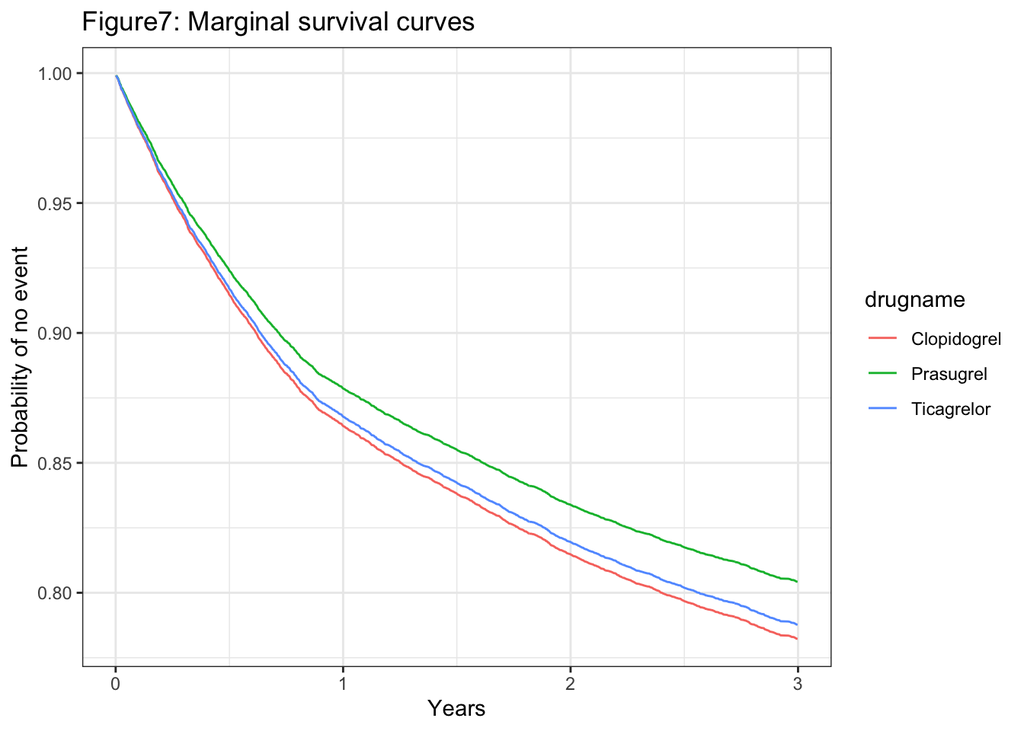

```r
## Create counterfactual dataframes for each drug
df_Clopidogrel <- df %>% mutate(drugname = factor(rep("Clopidogrel", nrow(df)),
                                                  levels=c("Clopidogrel", "Prasugrel", "Ticagrelor")))
df_Prasugrel <- df %>% mutate(drugname = factor(rep("Prasugrel", nrow(df)),
                                                  levels=c("Clopidogrel", "Prasugrel", "Ticagrelor")))
df_Ticagrelor <- df %>% mutate(drugname = factor(rep("Ticagrelor", nrow(df)),
                                                  levels=c("Clopidogrel", "Prasugrel", "Ticagrelor")))


## Predict survival at all times for each of the three counterfactual dataframes
survpred_Clopidogrel <- survfit(coxph_drugs_weighted, newdata = df_Clopidogrel, censor = FALSE)
survpred_Prasugrel <- survfit(coxph_drugs_weighted, newdata = df_Prasugrel, censor = FALSE)
survpred_Ticagrelor <- survfit(coxph_drugs_weighted, newdata = df_Ticagrelor, censor = FALSE)


# Average over each individual
marginal_survpred_Clopidogrel <- rowMeans(survpred_Clopidogrel$surv)
marginal_survpred_Prasugrel <- rowMeans(survpred_Prasugrel$surv)
marginal_survpred_Ticagrelor <- rowMeans(survpred_Ticagrelor$surv)


## Plot marginal survival via base R plot functions
# par(mfrow=c(1,1))
# plot(y=marginal_survpred_Clopidogrel, x=survpred_Clopidogrel$time, col="red", type="n")
# lines(marginal_survpred_Clopidogrel, x=survpred_Clopidogrel$time, col="red")
# lines(marginal_survpred_Prasugrel, x=survpred_Prasugrel$time, col="green")
# lines(marginal_survpred_Ticagrelor, x=survpred_Ticagrelor$time, col="blue")


## Create dataframe for ggplotting and RMST calculation
df_ggplot <- data.frame(drugname=rep(c("Clopidogrel", "Prasugrel", "Ticagrelor"), each=length(survpred_Clopidogrel$time)),
                        time=c(survpred_Clopidogrel$time, survpred_Clopidogrel$time, survpred_Clopidogrel$time),
                        survival=c(marginal_survpred_Clopidogrel, marginal_survpred_Prasugrel, marginal_survpred_Ticagrelor))
df_ggplot$drugname <- factor(df_ggplot$drugname, levels=c("Clopidogrel", "Prasugrel", "Ticagrelor"))


## Create ggplot and save it
Fig7 <- ggplot(data=df_ggplot) +
            geom_line(aes(x=time,y=survival, group=drugname, col=drugname)) +
            theme_bw() +  ylab("Probability of no event") +
            xlab("Years") + ggtitle("Figure7: Marginal survival curves")
ggsave(filename = "../output/figures/Fig7__MainAnalysis_marginalSurvival.pdf", plot=Fig7)
print(Fig7)
```

```r
# adjcurve_standardization = adjustedCurves::adjustedsurv(data = df, variable = "drugname",
#                                                         ev_time = "time_to_event_years", event = "last_status",
#                                                         method = "direct", outcome_model = coxph_drugs_weighted,
#                                                         conf_int = FALSE)
#
# plot(adjcurve_standardization, conf_int = TRUE,
#      custom_colors = c("red", "green","blue"),
#      xlab = "Years", legend.title = "", ylim = c(0.75, 1))


# note: This code produces the same curves as the code block above
```

```r
## Write function to compute RMST based on survival curve
calc_RMST <- function(df_surv){
  #trapz(df_surv$time, df_surv$survival) # from package pracma
  sum(c(0, diff(df_surv$time)*(head(df_surv$survival, -1) + tail(df_surv$survival, -1))/2))
}


## Calculate RMST for each drug
RMST_Clopidogrel <- df_ggplot %>% filter(drugname == "Clopidogrel") %>% calc_RMST() %>% round(., digits=4)
RMST_Prasugrel <- df_ggplot %>% filter(drugname == "Prasugrel") %>% calc_RMST() %>% round(., digits=4)
RMST_Ticagrelor <- df_ggplot %>% filter(drugname == "Ticagrelor") %>% calc_RMST() %>% round(., digits=4)
df_res <- data.frame(drugname=c("Clopidogrel", "Prasugrel", "Ticagrelor"),
                     RMST = c(RMST_Clopidogrel, RMST_Prasugrel, RMST_Ticagrelor))


## Print results
print(df_res)
```

```
##      drugname   RMST
## 1 Clopidogrel 2.5514
## 2   Prasugrel 2.5976
## 3  Ticagrelor 2.5629
```

Result: The estimated RMST for Clopidogrel: 2.5514; The estimated RMST for Prasugrel: 2.5976; The estimated RMST for Ticagrelor: 2.5629

## Session Info

```r
## Remove redundant objects
rm(list=c("df", "df_Clopidogrel", "df_ggplot", "df_Prasugrel",
          "df_prob_inhib", "df_Ticagrelor", "survpred_Clopidogrel", "survpred_Prasugrel", "survpred_Ticagrelor",
          "marginal_survpred_Clopidogrel", "marginal_survpred_Prasugrel", "marginal_survpred_Ticagrelor",
          "p_marginal"))


## Save image
fname <- paste0("../data/Rsession_analysis_main", Sys.Date(), ".RData")
save.image(file = fname)


## Print session info
```

[output not shown]